# Replication #4

Jack Schroeder

3/12/2019

## Replication

### Figure 1. Treatment Effects

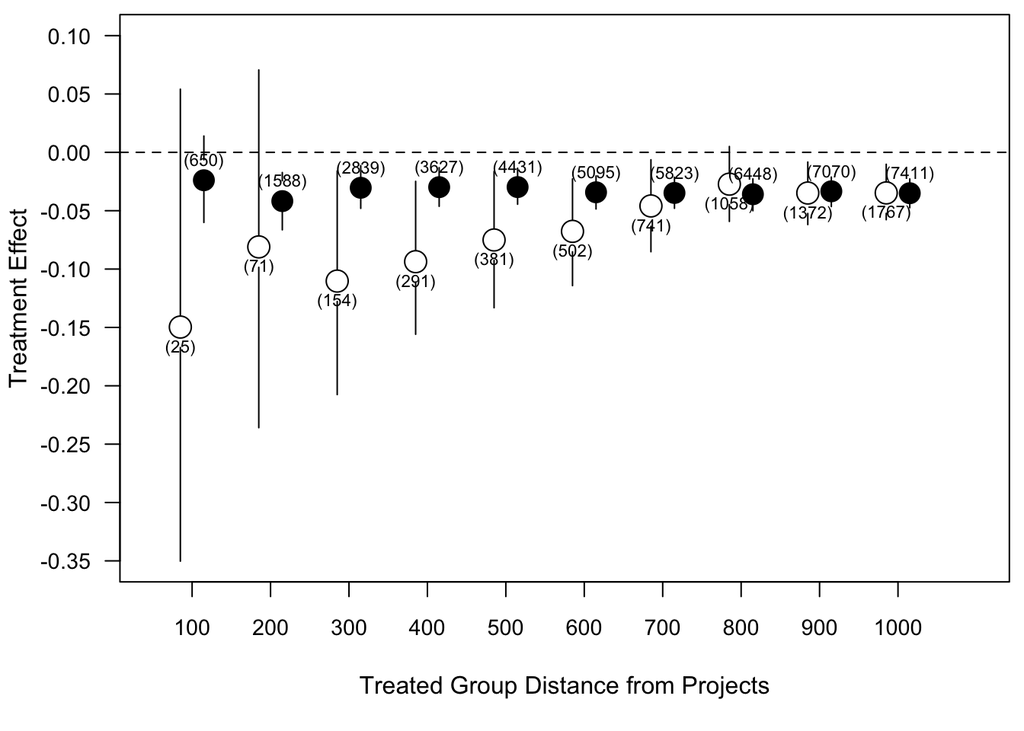

Note: Difference-in-differences results for treatment groups defined by increasing distance from the demolished projects. Differences are for the mean turnout in 2004 minus the mean turnout in 2000 for the treatment group minus the same difference for the control group. White circles represent the mean effect on white voters; black circles represent the mean effect on black voters. The N in each treatment group is in parentheses next to the mean effect. Vertical lines represent the 95% confidence intervals generated by bootstrapped standard errors of the difference between treatment and control.

### Figure 2. Treatment Effects Using Matched White Voters Near Nondemolished Projects for Control Group

### Figure 3. Treatment Effects Using Matched Black Control Group and Controlling for Homeownership

[figure not shown]

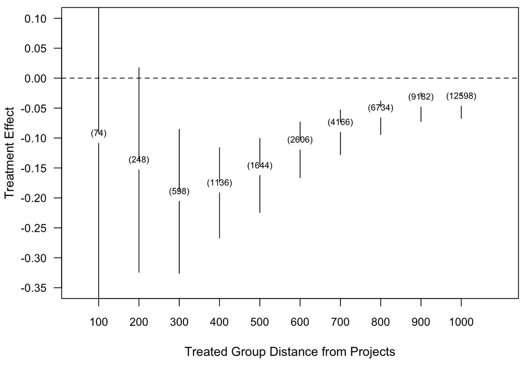

### Figure 4. Effects of Distance and Size of Projects

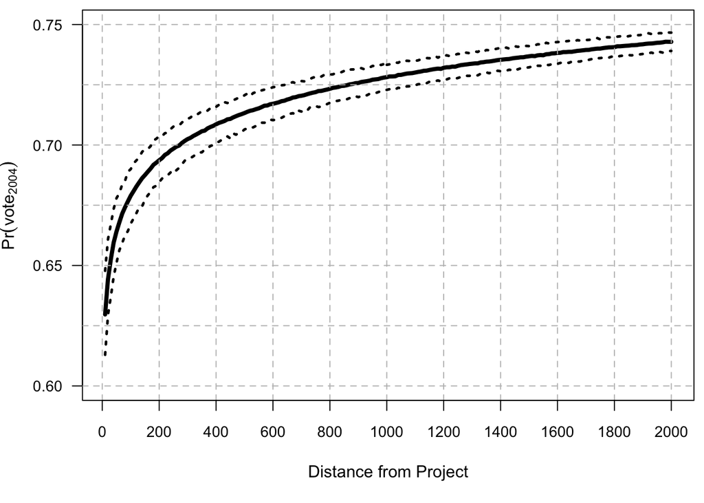

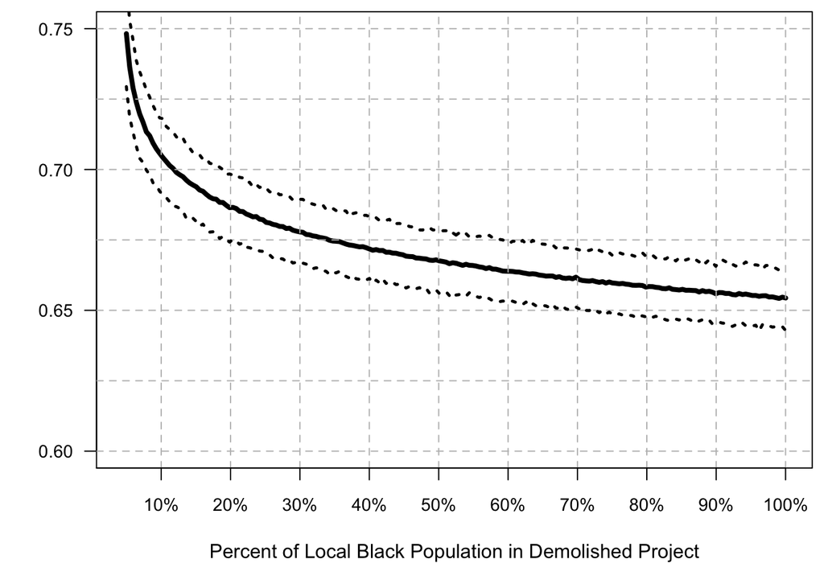

Note: Predicted effects generated from $vote2004 = 0 + 1(log(distance)) + 2(log(localpercent)) + vote2000$, with white voters. Figure 4(a) is the predicted probability that a person who voted in 2000 will vote in 2004 with increasing distance, while holding size at its mean. Figure 4(b) is the predicted probability that a person who voted in 2000 will vote in 2004, with increasing outgroup population size, with distance = 100. Dotted lines represent 95% confidence intervals generated by bootstrapped standard errors.

### Figure 5. Difference in Republican Vote for Matched Precincts

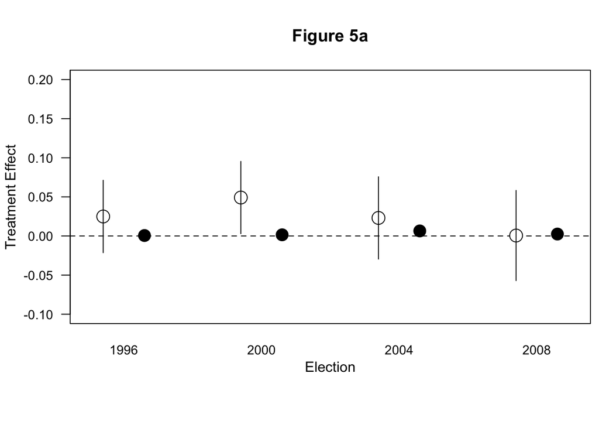

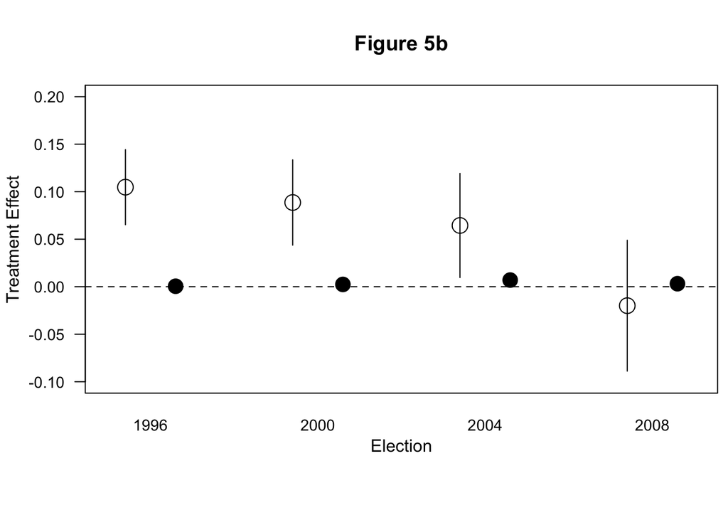

Note: Figure 5(a) shows differences in weighted mean Republican vote for precincts with $d ≤ 1,000$ and matched precincts with $d > 1,000$ for white voters (white circles) and black voters (black circles). Figure 5(b) shows differences in weighted mean Republican vote for white voters and black voters matched with precincts with $d ≤ 1,000$ from nondemolished projects.

### Figure 6. Difference in Obama Vote for Matched Precincts

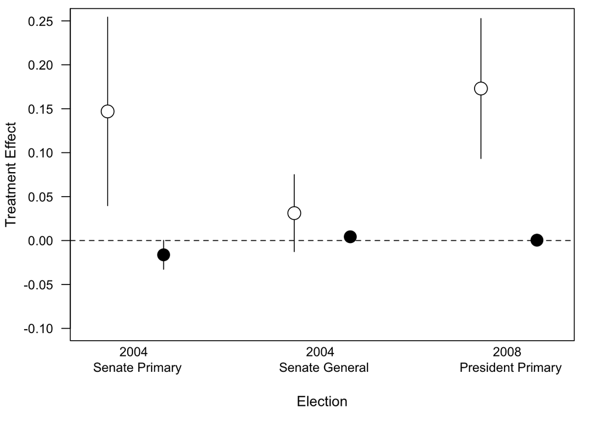

Note: Note: Differences in weighted mean Obama vote for precincts with $d ≤ 1,000$ for de- molished projects and matched precincts with $d ≤ 1,000$ for nondemolished projects for white voters (white circles) and black voters (black circles).

### Table 1. Regression of Turnout on Distance and Population Size

|  | *Dependent variable:* |
| --- | --- |
|  | vote2004 |
| log(demo.distance) | 0.021*** |
|  | (0.001) |
| log(context_black) | -0.018*** |
|  | (0.002) |
| vote2000 | 0.420*** |
|  | (0.003) |
| Constant | 0.136*** |
|  | (0.012) |
| Observations | 113,851 |
| R<sup>2</sup> | 0.119 |
| Adjusted R<sup>2</sup> | 0.119 |
| Residual Std. Error | 0.429 (df = 113847) |
| F Statistic | 5,134.152*** (df = 3; 113847) |
| *Note:* | p<0.1; p<0.05; p<0.01 |

## References

Enos, R. (2015). What the demolition of public hosuing teaches us about the imapct of racial threat on political behavior. *American Journal of Political Science 0*(0). pp. 1-20.

Enos, R. (2015). Replication data for: What the demolition of public housing teaches us about the impact of racial threat on political behavior. *Harvard Dataverse*. Reached at dataverse.harvard.edu